# Classification of news headlines with impact on the probability of stock prices changes

Max Franke

April 28, 2020

Course: CIS-627 CAPSTONE

Term: Spring/T2

# Capstone Project

## Approach

In this analysis, the following approach will be used: - The following is a list of the most important topics:

### 0. Workspace preparation

- This section will clean the workspace, load the libraries, the datasets and prepare the datasets as followed:
- The news dataset will transformed, so that there will be three datasets:
1. Original Date
2. Date - 5 minutes
3. Date + 5 minutes

Then the datasets for the stocks will be loaded (for the start just the symbol AAPL)

### 1. Merge the data sets

- The analysis starts with two datasets: Healines from 2019/2020 (1) and the Close stock prices from Apple (2) - Note: Later on, this approach will be rolled out for all companies in the [Dow Jones Industrial Average](https://money.cnn.com/data/dow30/)
- The merging process will be done via the Date as a key and for all three Date options

### 2. Creating input data

- Transforming the news to serve as an input for the model.
- The result of preprocessing the data should be:

[output not shown]

### 3. Distribution of the data

- Analysis about some relationships and distributions (e.g. how many price changes do we have?)

### 4. Model Building

- Develop the convolutional neural network which takes as input the transformed news

### 5. Model Evaluation

- Check the model performance: Accuracy, overfitting etc.

### 6. Model Optimization

## Workspace preparation

### Approach

In this section the workspace will be prepared. This means that first the global environment will be cleaned, and all required packages will be loaded.

### Clean Workspace

```r
rm(list = ls())
```

### Install libraries

```r
## Install packages
my_packages <- c("plotly", "tidyverse", "reshape", "keras")
#install.packages(my_packages, repos = "http://cran.rstudio.com")
```

### Load packages

```r
library(tidyverse)
library(plotly)
library(reshape)
library(keras)
```

### Load news Dataset

```r
## Load data of stocks with headlines and description
setwd("/Users/MaxFranke/Desktop/05_Big Data Analytics/04_Classes/04 SP:Term2/CIS-627 CAPSTONE/News-Classification/02_Data/01_NewsApi")
news <- read.csv("News - 2019-2020.csv")
```

### Transform data

```r
# Names of dataframe
names(news) <- c("Date", "headline", "description")

# Past
past <- news
past$Date <- strptime(past$Date, format = "%m/%d/%y %H:%M") - 5*60
knitr::kable(head(past, 3), format = "markdown")
```

| Date | headline | description |
| --- | --- | --- |
| 2019-01-20 11:06:00 | JD(U) to vote against citizenship bill in Rajya Sabha |  |
| 2019-01-20 11:12:00 | Gillibrand: Previous immigration stances weren’t ‘empathetic,’ ‘kind’ | Democratic Sen. Kirsten Gillibrand said Sunday that her previous controversial stances on immigration “certainly weren’t empathetic and they were not kind.” |
| 2019-01-20 07:42:00 | Pak name new-look team for Pro-League Hockey, drop 11 players from WC side | Pakistan selectors on Sunday effected a wholesale change in the country’s hockey squad for the FIH Pro-League series beginning next month by dropping 11 players, including captain Muhammad Rizwan, who… |

```r
# Future
future <- news
future$Date <- strptime(future$Date, format = "%m/%d/%y %H:%M") + 5*60
knitr::kable(head(future, 3), format = "markdown")
```

| Date | headline | description |
| --- | --- | --- |
| 2019-01-20 11:16:00 | JD(U) to vote against citizenship bill in Rajya Sabha |  |
| 2019-01-20 11:22:00 | Gillibrand: Previous immigration stances weren’t ‘empathetic,’ ‘kind’ | Democratic Sen. Kirsten Gillibrand said Sunday that her previous controversial stances on immigration “certainly weren’t empathetic and they were not kind.” |
| 2019-01-20 07:52:00 | Pak name new-look team for Pro-League Hockey, drop 11 players from WC side | Pakistan selectors on Sunday effected a wholesale change in the country’s hockey squad for the FIH Pro-League series beginning next month by dropping 11 players, including captain Muhammad Rizwan, who… |

```r
# present
news$Date <- strptime(news$Date, format = "%m/%d/%y %H:%M") + 5*60 - 5*60
knitr::kable(head(news, 3), format = "markdown")
```

| Date | headline | description |
| --- | --- | --- |
| 2019-01-20 11:11:00 | JD(U) to vote against citizenship bill in Rajya Sabha |  |
| 2019-01-20 11:17:00 | Gillibrand: Previous immigration stances weren’t ‘empathetic,’ ‘kind’ | Democratic Sen. Kirsten Gillibrand said Sunday that her previous controversial stances on immigration “certainly weren’t empathetic and they were not kind.” |
| 2019-01-20 07:47:00 | Pak name new-look team for Pro-League Hockey, drop 11 players from WC side | Pakistan selectors on Sunday effected a wholesale change in the country’s hockey squad for the FIH Pro-League series beginning next month by dropping 11 players, including captain Muhammad Rizwan, who… |

### Load APPL dataset

```r
setwd("/Users/MaxFranke/Desktop/05_Big Data Analytics/04_Classes/04 SP:Term2/CIS-627 CAPSTONE/News-Classification/02_Data/03_stocks")
apple <- read.csv("AAPL.USUSD_Candlestick_1_M_BID_01.01.2019-21.04.2020.csv")
```

### Transform data

```r
apple$Local.time <- strptime(apple$Local.time, format = "%d.%m.%Y %H:%M")
rownames(apple) <- NULL
apple <- apple[,1:5]
names(apple) <- c("Date", "Open", "High", "Low", "Close")
apple$Date <- apple$Date + 5*60 - 5*60
knitr::kable(head(apple, 3), format = "markdown")
```

| Date | Open | High | Low | Close |
| --- | --- | --- | --- | --- |
| 2019-01-01 00:00:00 | 157.718 | 157.718 | 157.718 | 157.718 |
| 2019-01-01 00:01:00 | 157.718 | 157.718 | 157.718 | 157.718 |
| 2019-01-01 00:02:00 | 157.718 | 157.718 | 157.718 | 157.718 |

## Merging datsets

### Merge

```r
# present
merge <- merge(news, apple, by = "Date", sort = FALSE)
knitr::kable(head(merge, 3), format = "markdown")
```

| Date | headline | description | Open | High | Low | Close |
| --- | --- | --- | --- | --- | --- | --- |
| 2019-01-20 11:11:00 | JD(U) to vote against citizenship bill in Rajya Sabha |  | 156.787 | 156.787 | 156.787 | 156.787 |
| 2019-01-20 11:11:00 | Even Tom Holland Believed A Spoof Article Saying He Leaked Avengers 4 Online | Because if anyone is likely to really do that … it’s Mark Ruffalo. But also “Spoiler-Man” Tom Holland. | 156.787 | 156.787 | 156.787 | 156.787 |
| 2019-01-20 11:17:00 | Gillibrand: Previous immigration stances weren’t ‘empathetic,’ ‘kind’ | Democratic Sen. Kirsten Gillibrand said Sunday that her previous controversial stances on immigration “certainly weren’t empathetic and they were not kind.” | 156.787 | 156.787 | 156.787 | 156.787 |

```r
# Past
merge_past <- merge(past, apple, by = "Date", sort = FALSE)
knitr::kable(head(merge_past, 3), format = "markdown")
```

| Date | headline | description | Open | High | Low | Close |
| --- | --- | --- | --- | --- | --- | --- |
| 2019-01-20 11:06:00 | JD(U) to vote against citizenship bill in Rajya Sabha |  | 156.787 | 156.787 | 156.787 | 156.787 |
| 2019-01-20 11:06:00 | Even Tom Holland Believed A Spoof Article Saying He Leaked Avengers 4 Online | Because if anyone is likely to really do that … it’s Mark Ruffalo. But also “Spoiler-Man” Tom Holland. | 156.787 | 156.787 | 156.787 | 156.787 |
| 2019-01-20 11:12:00 | Gillibrand: Previous immigration stances weren’t ‘empathetic,’ ‘kind’ | Democratic Sen. Kirsten Gillibrand said Sunday that her previous controversial stances on immigration “certainly weren’t empathetic and they were not kind.” | 156.787 | 156.787 | 156.787 | 156.787 |

```r
# Future
merge_future <- merge(future, apple, by = "Date", sort = FALSE)
knitr::kable(head(merge_past, 3), format = "markdown")
```

| Date | headline | description | Open | High | Low | Close |
| --- | --- | --- | --- | --- | --- | --- |
| 2019-01-20 11:06:00 | JD(U) to vote against citizenship bill in Rajya Sabha |  | 156.787 | 156.787 | 156.787 | 156.787 |
| 2019-01-20 11:06:00 | Even Tom Holland Believed A Spoof Article Saying He Leaked Avengers 4 Online | Because if anyone is likely to really do that … it’s Mark Ruffalo. But also “Spoiler-Man” Tom Holland. | 156.787 | 156.787 | 156.787 | 156.787 |
| 2019-01-20 11:12:00 | Gillibrand: Previous immigration stances weren’t ‘empathetic,’ ‘kind’ | Democratic Sen. Kirsten Gillibrand said Sunday that her previous controversial stances on immigration “certainly weren’t empathetic and they were not kind.” | 156.787 | 156.787 | 156.787 | 156.787 |

```r
# Past
merge_past$Date_present <- merge_past$Date + 5*60
names(merge_past) <- c("Date_Past", "headline", "description", "Open", "High", "Low", "Close_past", "Date")

knitr::kable(head(merge_past[,c(1,2,4:8)], 3), format = "markdown")
```

| Date_Past | headline | Open | High | Low | Close_past | Date |
| --- | --- | --- | --- | --- | --- | --- |
| 2019-01-20 11:06:00 | JD(U) to vote against citizenship bill in Rajya Sabha | 156.787 | 156.787 | 156.787 | 156.787 | 2019-01-20 11:11:00 |
| 2019-01-20 11:06:00 | Even Tom Holland Believed A Spoof Article Saying He Leaked Avengers 4 Online | 156.787 | 156.787 | 156.787 | 156.787 | 2019-01-20 11:11:00 |
| 2019-01-20 11:12:00 | Gillibrand: Previous immigration stances weren’t ‘empathetic,’ ‘kind’ | 156.787 | 156.787 | 156.787 | 156.787 | 2019-01-20 11:17:00 |

```r
# Future
merge_future$Date_present <- merge_future$Date - 5*60
names(merge_future) <- c("Date_Past", "headline", "description", "Open", "High", "Low", "Close_future", "Date")
knitr::kable(head(merge_future[,c(1,2,4:8)], 3), format = "markdown")
```

| Date_Past | headline | Open | High | Low | Close_future | Date |
| --- | --- | --- | --- | --- | --- | --- |
| 2019-01-20 11:16:00 | JD(U) to vote against citizenship bill in Rajya Sabha | 156.787 | 156.787 | 156.787 | 156.787 | 2019-01-20 11:11:00 |
| 2019-01-20 11:16:00 | Even Tom Holland Believed A Spoof Article Saying He Leaked Avengers 4 Online | 156.787 | 156.787 | 156.787 | 156.787 | 2019-01-20 11:11:00 |
| 2019-01-20 11:22:00 | Gillibrand: Previous immigration stances weren’t ‘empathetic,’ ‘kind’ | 156.787 | 156.787 | 156.787 | 156.787 | 2019-01-20 11:17:00 |

```r
# Result
result <- merge(merge, merge_past[,c(2,7:8)], by = c("Date", "headline"), sort = FALSE)
result <- merge(result, merge_future[,c(2,7:8)], by = c("Date", "headline"), sort = FALSE)

# Price change
result$PriceChange <- if_else(result$Close == result$Close_past & result$Close == result$Close_future, FALSE, TRUE)
knitr::kable(head(result[,c(1,2,4:10)], 3), format = "markdown")
```

| Date | headline | Open | High | Low | Close | Close_past | Close_future | PriceChange |
| --- | --- | --- | --- | --- | --- | --- | --- | --- |
| 2019-01-20 11:11:00 | JD(U) to vote against citizenship bill in Rajya Sabha | 156.787 | 156.787 | 156.787 | 156.787 | 156.787 | 156.787 | FALSE |
| 2019-01-20 11:11:00 | Even Tom Holland Believed A Spoof Article Saying He Leaked Avengers 4 Online | 156.787 | 156.787 | 156.787 | 156.787 | 156.787 | 156.787 | FALSE |
| 2019-01-20 11:17:00 | Gillibrand: Previous immigration stances weren’t ‘empathetic,’ ‘kind’ | 156.787 | 156.787 | 156.787 | 156.787 | 156.787 | 156.787 | FALSE |

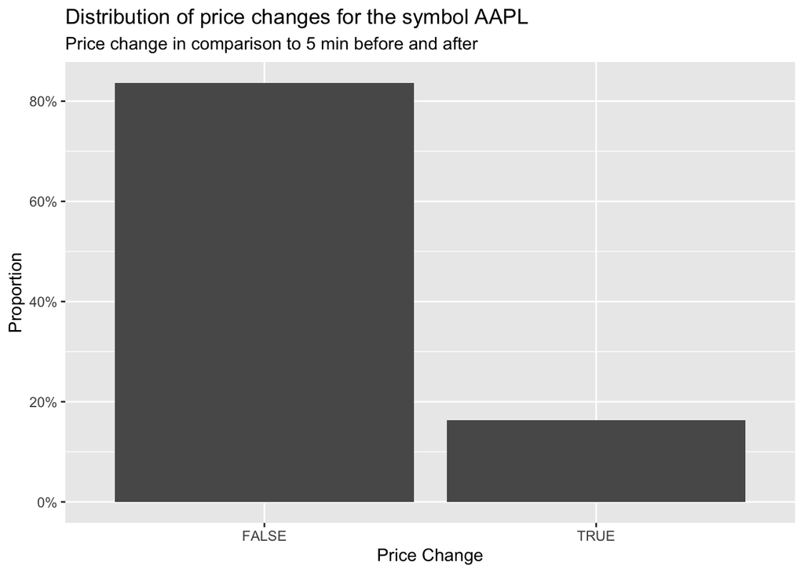

```r
# First look for a price change
ggplot(data = result, mapping = aes(x = PriceChange)) +
  geom_bar(mapping = aes(y = ..prop.., group = 1)) +
  guides(fill = FALSE) +
  scale_y_continuous(labels = scales::percent) +
  labs(title = "Distribution of price changes for the symbol AAPL",
       subtitle = "Price change in comparison to 5 min before and after",
       y = "Proportion",
       x = "Price Change")
```

## Creating input data

Tokenizers

```r
# converting the headlines into a sequence of integers
text <- result$headline
```

Number of words

```r
max_features <- 1000
tokenizer <- text_tokenizer(num_words = max_features)
```

Fit to the headlines

```r
tokenizer %>% fit_text_tokenizer(text)
```

Number of documents

```r
tokenizer$document_count
```

```
## [1] 130684
```

Word-Index list

```r
tokenizer$word_index %>% head()
```

```
## $`'crpf`
## [1] 43442
##
## $nordisk
## [1] 25508
##
## $raining
## [1] 32002
##
## $deferment
## [1] 19005
##
## $`considered'`
## [1] 52914
##
## $sonja
## [1] 28741
```

List of integers

```r
text_seqs <- texts_to_sequences(tokenizer, text)
knitr::kable(text_seqs %>% head(), format = "html")
```

| x |
| --- |
| 18 |
| 1 |
| 375 |
| 43 |
| 305 |
| 2 |
| 311 |

| x |
| --- |
| 714 |
| 8 |
| 186 |
| 46 |
| 564 |

| x |
| --- |
| 346 |

| x |
| --- |
| 623 |
| 16 |
| 363 |
| 161 |
| 3 |
| 746 |
| 245 |
| 405 |
| 198 |
| 500 |
| 19 |
| 838 |

| x |
| --- |
| 1 |
| 408 |
| 186 |
| 101 |
| 823 |
| 716 |

| x |
| --- |
| 143 |
| 523 |
| 2 |
| 30 |
| 814 |
| 704 |
| 6 |
| 524 |
| 244 |

## Distribution of the data

### Development of price changes

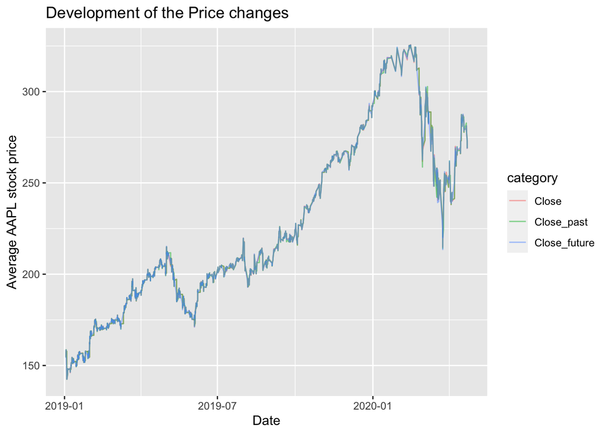

```r
priceChange <- subset(result, PriceChange == TRUE)
priceChange <- priceChange[,c(1,2,3,7,8,9)]
priceChange_plot <- melt(priceChange, id = c("Date", "headline", "description"))
names(priceChange_plot) <- c("Date", "headline", "description", "category", "ClosePrice")

plot <- priceChange_plot %>%
  dplyr::group_by(Date, category) %>%
  dplyr::summarize(Mean = mean(ClosePrice))

ggplot(data = plot, mapping = aes(x = Date, y = Mean, color = category)) +
  geom_line(alpha = .5) +
  labs(title = "Development of the Price changes",
       y = "Average AAPL stock price")
```

### Significantly different

```r
aov <- aov(Mean ~ category, data = plot)
summary(aov)
```

```
##                Df   Sum Sq Mean Sq F value Pr(>F)
## category        2        5     2.5   0.002  0.998
## Residuals   48816 56606203  1159.6
```

```r
TukeyHSD(aov)
```

```
##   Tukey multiple comparisons of means
##     95% family-wise confidence level
##
## Fit: aov(formula = Mean ~ category, data = plot)
##
## $category
##                                diff        lwr       upr     p adj
## Close_past-Close        -0.01235654 -0.8971344 0.8724213 0.9994095
## Close_future-Close       0.01226492 -0.8725129 0.8970427 0.9994182
## Close_future-Close_past  0.02462146 -0.8601564 0.9093993 0.9976576
```

## Model Building

Set parameters

```r
maxlen <- 100
batch_size <- 32
embedding_dims <- 50
filters <- 64
kernel_size <- 3
hidden_dims <- 50
epochs <- 50
```

Preprocessing the text

```r
x_train <- text_seqs %>% pad_sequences(maxlen = maxlen)
dim(x_train)
```

```
## [1] 130684    100
```

y-variable

```r
y_train <- result$PriceChange
length(y_train)
```

```
## [1] 130684
```

Model building

```r
model <- keras_model_sequential() %>%
  layer_embedding(max_features, embedding_dims, input_length = maxlen) %>%
  layer_dropout(0.5) %>%
  layer_conv_1d(
    filters, kernel_size,
    padding = "valid", activation = "relu", strides = 1) %>%
  layer_global_max_pooling_1d() %>%
  layer_dense(hidden_dims) %>%
  layer_dropout(0.5) %>%
  layer_activation("relu") %>%
  layer_dense(1) %>%
  layer_activation("sigmoid") %>% compile(
  loss = "binary_crossentropy",
  optimizer = "adam",
  metrics = "accuracy"
)
```

## Model Performance

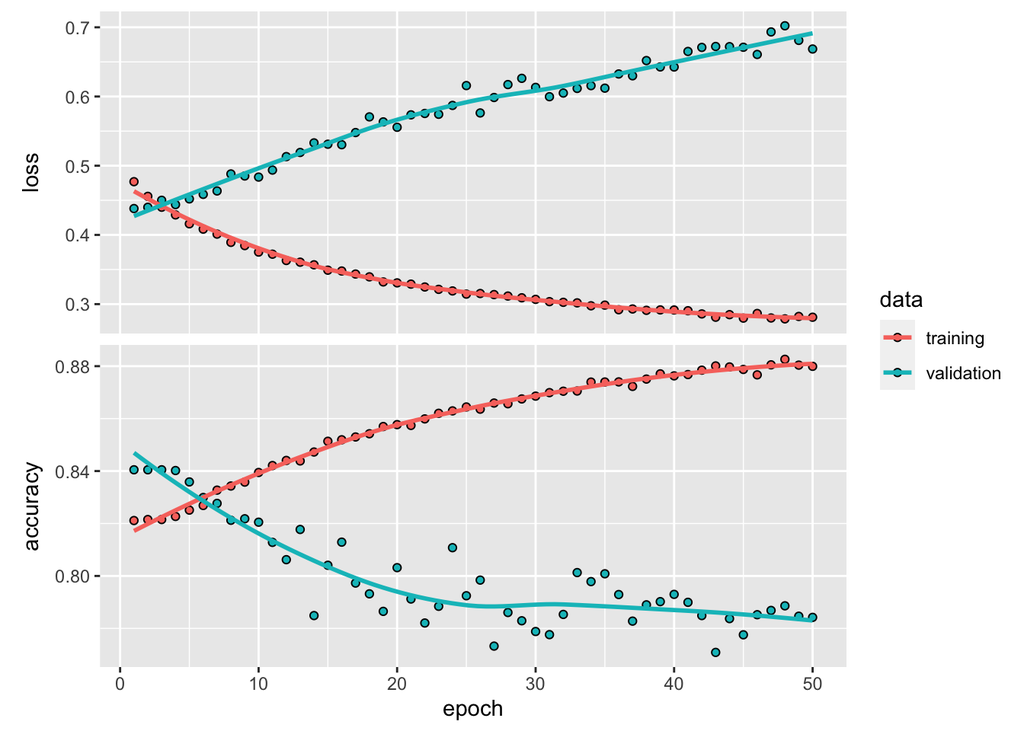

```r
hist <- model %>%
  fit(
    x_train,
    y_train,
    batch_size = batch_size,
    epochs = epochs,
    validation_split = 0.8
  )
plot(hist)
```